# Ep-03

Benjamín Hernandez | Marco Ortiz | Benjamín Paredes

2026-04-15

# Contexto:

### En una planta química hay dos máquinas que envasan detergentes industriales en bidones con un volumen de producto que sigue una distribución normal con desviación estándar de 1 litro. La ingeniera a cargo de la planta debe asegurar que los bidones se están llenando con una media de 10 litros. Pero ella tiene la sospecha de que hay desviaciones en esta media, lo que piensa confirmar usando una muestra aleatoria de 100 envases (50 de cada una de las máquinas). También cree que hay diferencia en el cumplimiento del volumen requerido entre la máquina más antigua y la más moderna, que han de andar por el 90% y 96% de los bidones, respectivamente.

```r
#Desviacion estandar de 1 litro
desvEstandar <- 1
#La ingeniera de la planta se debe asegurar que los bidones se llenen en media de 10 litros
mediaLlenado <- 10
# Muestra aleatoria  de 100 envaces (50 envaces por maquina)
n = 100
#podemos calcular el error estandar de la media con la formula
errorEstandar <- desvEstandar/sqrt(n)
# Diferencia en el cumplimiento del volumen requerido entre la maquina mas antigua y la mas moderna, que esta entre el 90% y 96% de los bidones
# Ho es que la media de llenado es = 10
```

# Equipo 1:

### 1.- Si la ingeniera piensa rechazar la hipótesis nula cuando la muestra presente una media menor a 9,78 litros o mayor a 10,22 litros, ¿cuál es la probabilidad de que cometa un error de tipo I? Para responder, generen un gráfico de la distribución muestral de las medias hipotetizada en donde se marquen las zonas correspondientes a la probabilidad solicitada, para luego, basándose en este gráfico, calcular el área correspondiente. Tome como ejemplo los scripts presentados en la lectura sobre poder estadístico.

¿Qué debemos determinar o resolver? Se nos pide identificar cual es la probabilidad de rechazar la hipótesis nula cuando esta es en realidad verdadera, ademas se nos pide realizar esto mediante el análisis gráfico

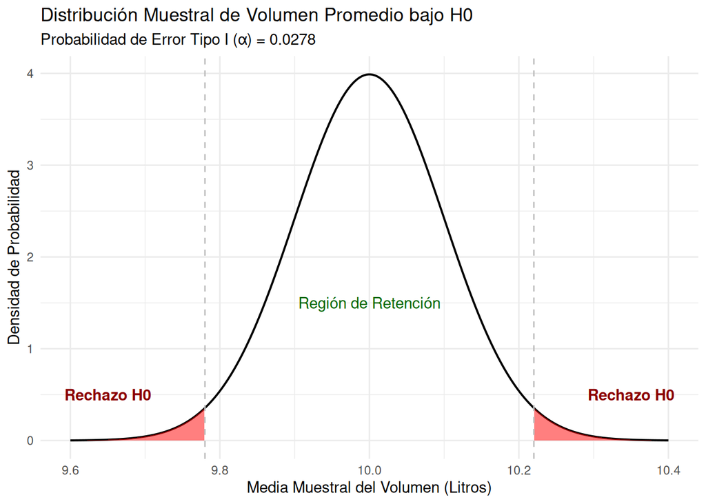

```r
# Rechazos
r1 <- 9.78
r2 <- 10.22

# Podriamos utilizar aca lo de estadistica computacional, como pnorm para que nos devuelva la probabilidad de que una variable sea menor o igual a un valor y lo separamos por las colas

pInf <- pnorm(r1, mean = mediaLlenado, sd = errorEstandar)

pSup <- pnorm(r2, mean = mediaLlenado, sd = errorEstandar, lower.tail = FALSE)

# Acá ya tenemos la probabilidad total de ser rechazada la ho
pGeneral <- pInf + pSup

#Creamos una secuencia de datos para poder hacer el grafico, por lo que sale en el capitulo 3-4, sabemos que cerca del 99.7% de las observaciones se encuentran a una distancia de tres desviaciones estandar de la media, por lo que para asegurar ocuparemos 4
x <- seq(mediaLlenado - 4* errorEstandar, mediaLlenado +4*errorEstandar, length.out = 1000)

# Caclulamos la densidad de probabilidad para obtener el Y de la grafica
y <- dnorm(x, mean = mediaLlenado, sd = errorEstandar)

# Creamos el dataframe para graficarlo
data <- data.frame(x =x, y = y)

# Filtramos los datos para sombrear
zonaR1 <- subset(data, x <= r1)
zonaR2 <- subset(data, x >= r2)

g <- ggplot(data, aes(x = x, y = y)) +
  geom_line(color = "black", size = 0.7) +
  geom_area(data = zonaR1, fill = "red", alpha = 0.5) +
  geom_area(data = zonaR2, fill = "red", alpha = 0.5) +
  geom_vline(xintercept = c(r1, r2), linetype = "dashed", color = "grey") +
  labs(title = "Distribución Muestral de Volumen Promedio bajo H0",
       subtitle = paste("Probabilidad de Error Tipo I (\u03b1) =", round(pGeneral, 4)),
       x = "Media Muestral del Volumen (Litros)",
       y = "Densidad de Probabilidad") +
  theme_minimal() +
  annotate("text", x = 9.65, y = 0.5, label = "Rechazo H0", color = "darkred", fontface = "bold") +
  annotate("text", x = 10.35, y = 0.5, label = "Rechazo H0", color = "darkred", fontface = "bold") +
  annotate("text", x = 10, y = 1.5, label = "Región de Retención", color = "darkgreen")
g
```

```r
pGeneral
```

```
## [1] 0.0278069
```

Respuesta:  
Basandonos en el grafico realizado, las zonas sombreadas en las colas representan la probabilidad de rechazar la hipótesis nula (H_0). Por lo tanto, la probabilidad de que la ingeniera cometa un error del tipo 1, es de 0.0278069. Esto significa que hay aproximadamente un 2.78% de probabilidad de que concluya erróneamente que las maquinas están fallando, es decir, que la media de llenado es diferente a los 10 litros, cuando en realidad están funcionando de manera correcta.

### 2.- Si el verdadero volumen medio de los bidones fuera de 10,2 litros, ¿cuál sería la probabilidad de que la ingeniera, que obviamente no conoce este dato, cometa un error de tipo II? Para responder, agregue al gráfico anterior la verdadera distribución muestral de las medias y marquen (con otro color) la zona correspondiente a la probabilidad solicitada, para luego, basándose en este gráfico, calcular el área correspondiente. También hay ejemplos de este procedimiento en la lectura sobre poder estadístico.

¿Qué debemos determinar o resolver?

Análisis:  
- El error tipo II ocurre cuando se queda con la Hipótesis nula (Ho) a pesar de estar equivocada.  
Para nuestro caso el planteamiento sería:  
La ingeniera cree que todo sigue funcionando correctamente (Es decir, considerando la media en 10, ya que ella no sabe el valor real). Ahora bien, como ella fijó limites entre 9,78 y 10,22, cualquier muestra que caiga en ese intervalo lo tomará por correcto, es por ello que lo correcto (Y bueno, por algo es mencionado en la misma pregunta) es realizar la comparativa entre la gráfica que ella considera verdadera (Con la media en 10) y la que realmente es la verdadera (Con la media en 10,2)

```r
# Valor verdadero del volumen medio de los bideones
volMedioReal <- 10.2

# Calculamos la probabilidad de caer dentro del error tipo II
# Lo calculamos con la diferencia entre la probabilidad acumulada hasta r2 y la probabilidad acumulada de r1
pAcumuladaR2 <- pnorm(r2, mean = volMedioReal, sd = errorEstandar)
pAcumuladaR1 <- pnorm(r1, mean = volMedioReal, sd = errorEstandar)

beta <- pAcumuladaR2 - pAcumuladaR1

# Valor de beta
beta
```

```
## [1] 0.5792464
```

```r
# Valor de beta visto en %
betaPorcentaje <- beta*100
betaPorcentaje
```

```
## [1] 57.92464
```

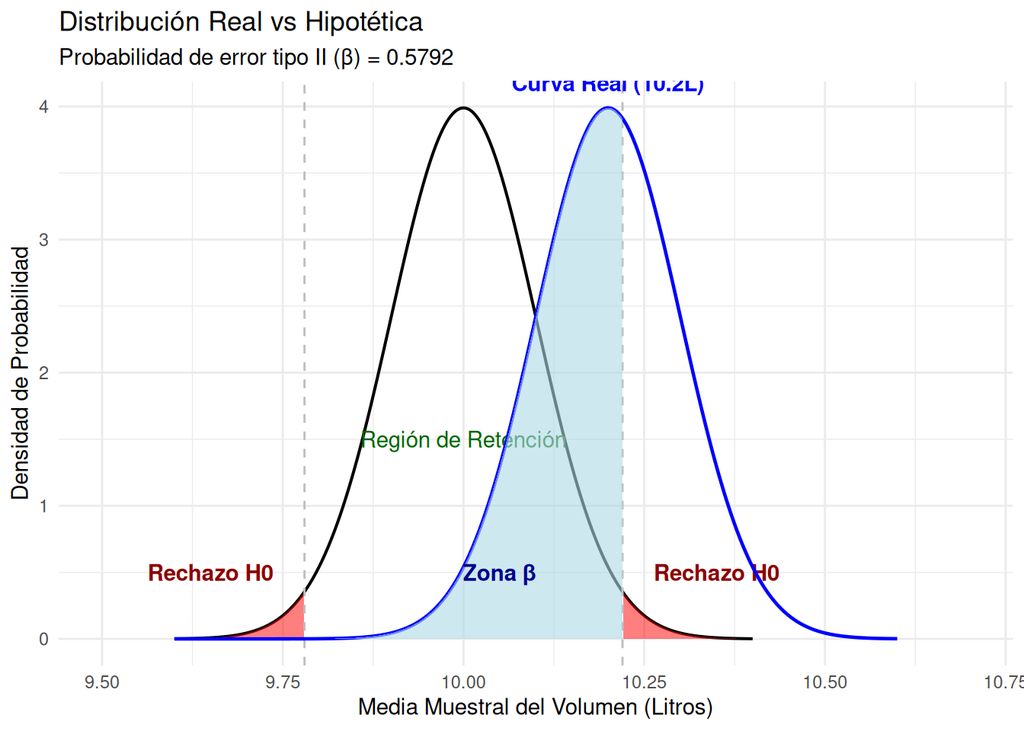

```r
# Mantenemos los datos para gráficar
x_HA <- seq(mediaLlenado - 4*errorEstandar, volMedioReal + 4*errorEstandar, length.out = 1000)
y_HA <- dnorm(x_HA, mean = volMedioReal, sd = errorEstandar)
data_HA <- data.frame(x = x_HA, y = y_HA)

# Hacemos un "Sub-gráfico" con la zona de la probabilidad de error tipo II
zonaBeta <- subset(data_HA, x >= r1 & x <= r2)

# Actualizamos el gráfico g de la pregunta anterior para hacer la comparación
g_actualizado <- g +
  # Curva de la distribución real
  geom_line(data = data_HA, aes(x = x, y = y), color = "blue", size = 0.8) +
  # Esta es el área sombreada del error tipo II
  geom_area(data = zonaBeta, aes(x = x, y = y), fill = "lightblue", alpha = 0.6) +
  labs(title = "Distribución Real vs Hipotética",
       subtitle = paste("Probabilidad de error tipo II (\u03b2) =", round(beta, 4))) +
  annotate("text", x = 10.2, y = max(y_HA), label = "Curva Real (10.2L)", color = "blue", vjust = -1, fontface = "bold") +
  annotate("text", x = 10.05, y = 0.5, label = "Zona \u03b2", color = "darkblue", fontface = "bold") +
  coord_cartesian(xlim = c(9.5, 10.7))
g_actualizado
```

Respuesta:  
Finalmente como podemos apreciar la probabilidad de la ingeniera de caer en un error de tipo II es aproximadamente del 57%-58%, todo esto justificandose del estudio y análisis realizado.

### 3.- Como no se conoce el verdadero volumen medio, genere un gráfico del poder estadístico con las condiciones anteriores, pero suponiendo que el verdadero volumen medio podría variar de 9,5 a 10,5 litros. Hay un ejemplo de este tipo de gráfico en la lectura sobre poder estadístico.

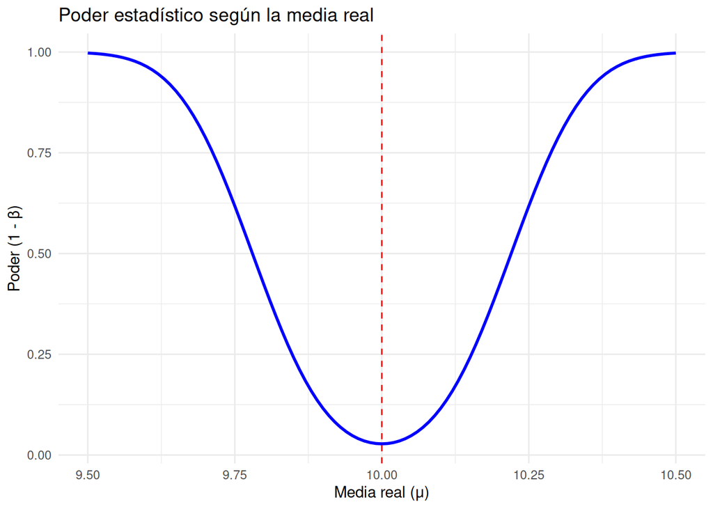

```r
medias <- seq(9.5, 10.5, by = 0.01)

# Calcular beta (error tipo II) para cada media
beta <- pnorm(10.22, mean = medias, sd = errorEstandar) -
        pnorm(9.78, mean = medias, sd = errorEstandar)

# Calcular poder estadístico
poder <- 1 - beta

# Crear dataframe
df_poder <- data.frame(mu = medias, poder = poder)

# Graficar
ggplot(df_poder, aes(x = mu, y = poder)) +
  geom_line(color = "blue", size = 1) +
  geom_vline(xintercept = 10, linetype = "dashed", color = "red") +
  labs(title = "Poder estadístico según la media real",
       x = "Media real (μ)",
       y = "Poder (1 - β)") +
  theme_minimal()
```

Respuesta: Como se puede observar enn el gráfico, la curva de poder estadístico tiene forma de valle centrado en los 10 litros. Esto demuestra que la capacidad de la ingeniera para detectar correctamente un fallo en el llenado aumenta a medida que el verdadero volumen medio de los bidones se aleja del valor esperado. Si la maquina se descalibra solo levemente, el poder estadístico es sumamente bajo, por lo que es muy probable cometer un error de tipo2, fuera del rango de aceptación, el poder estadístico crece rápidamente, hasta aumentar cerca del 1.

### 4.- Considerando la suposición de que el verdadero volumen medio de los bidones es de 10,2 litros, ¿cuántos bidones deberían revisarse para conseguir un poder estadístico de 0,75 y un nivel de significación de 0,05?

¿Qué debemos determinar o resolver?

```r
alfa <- 0.05
poder <- 0.75
delta <- volMedioReal - mediaLlenado
# d de Cohen
tamanoEfecto <- delta / desvEstandar

pwr.norm.test(d = tamanoEfecto,sig.level = alfa, power = poder, alternative = "two.sided")
```

```
##
##      Mean power calculation for normal distribution with known variance
##
##               d = 0.2
##               n = 173.5078
##       sig.level = 0.05
##           power = 0.75
##     alternative = two.sided
```

Respuesta: El análisis de poder estadístico indica que deberíamos revisar una muestra de al menos 174 (redondeando) bidones para poder conseguir 0.75 de poder estadístico con un nivel de significancia de 0.05

### 5.- ¿Alcanzaría esta muestra para detectar la diferencia que la ingeniera sospecha que existe entre las dos máquinas de la planta con al menos las mismas probabilidades de cometer errores?

¿Qué debemos determinar o resolver? Debemos verificar si la muestra calculada en el punto anterior, es suficiente para realizar una prueba de hipótesis para dos proporciones (90 y 96%) alcanzando las mismas probabilidades de error.

```r
pAntigua <- 0.9
pModerna <- 0.96

# Calcular cuanta muestra es necesario por maquina
nPorMaquina <- 174/2
muestras <- power.prop.test(p1 = pAntigua, p2= pModerna, sig.level = alfa, power = poder, alternative = "two.sided")

poderFinal <- power.prop.test(n= nPorMaquina ,p1 = pAntigua, p2= pModerna, sig.level = alfa, alternative = "two.sided")
muestras
```

```
##
##      Two-sample comparison of proportions power calculation
##
##               n = 250.1185
##              p1 = 0.9
##              p2 = 0.96
##       sig.level = 0.05
##           power = 0.75
##     alternative = two.sided
##
## NOTE: n is number in *each* group
```

```r
poderFinal
```

```
##
##      Two-sample comparison of proportions power calculation
##
##               n = 87
##              p1 = 0.9
##              p2 = 0.96
##       sig.level = 0.05
##           power = 0.340227
##     alternative = two.sided
##
## NOTE: n is number in *each* group
```

Respuesta: La muestra de 174 bidones no alcanzaría. El análisis de poder estadístico revelo que para detectar la diferencia entre un 90% y un 96% de cumplimiento con un nivel de significancia de 0.05 y un poder de 0.75, se necesitarían aproximadamente 250 bidones por máquina. Si la ingeniera utilizara la muestra de la pregunta 4 (174 bidones), el poder estadístico caería a un 34% aprox. Esto quiere decir que la probabilidad de cometer un error de tipo 2 aumentaría, fallando en mantener las mismas probabilidades de error solicitadas